# P4

Here, I’m loading in all the libraries I will be using for cleaning up and analyzing the resulting data. Specifically:

```r
library(ape)
library(tidyverse)
library(ggtree)
```

```r
library(reticulate)
py_install("pandas")
py_install("SciPy")
py_install("matplotlib")
py_install("BioPython")
```

## R Plots

Let’s load in our data!

```r
data <- read.csv("Data/rate_by_hand.csv")
```

I think some histograms would probably be the most useful first visualizations!

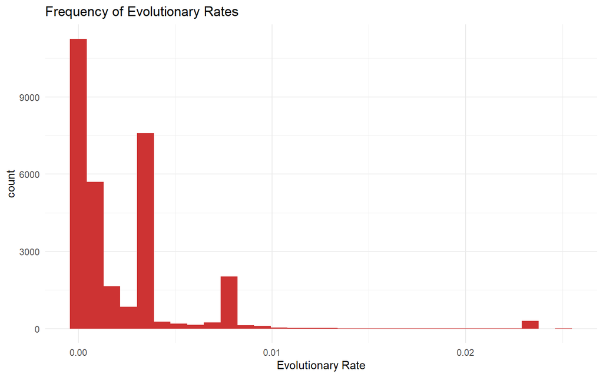

```r
ggplot(data, aes(x=rate))+
  geom_histogram(fill='brown3')+
  theme_minimal()+
  labs(title="Frequency of Evolutionary Rates", x="Evolutionary Rate")
```

So it looks like there are some outliers, probably due to incomplete data (Based on past work I’ve done) I’m interested in habitat and its effect on evolutionary rate, so let’s look at those histograms.

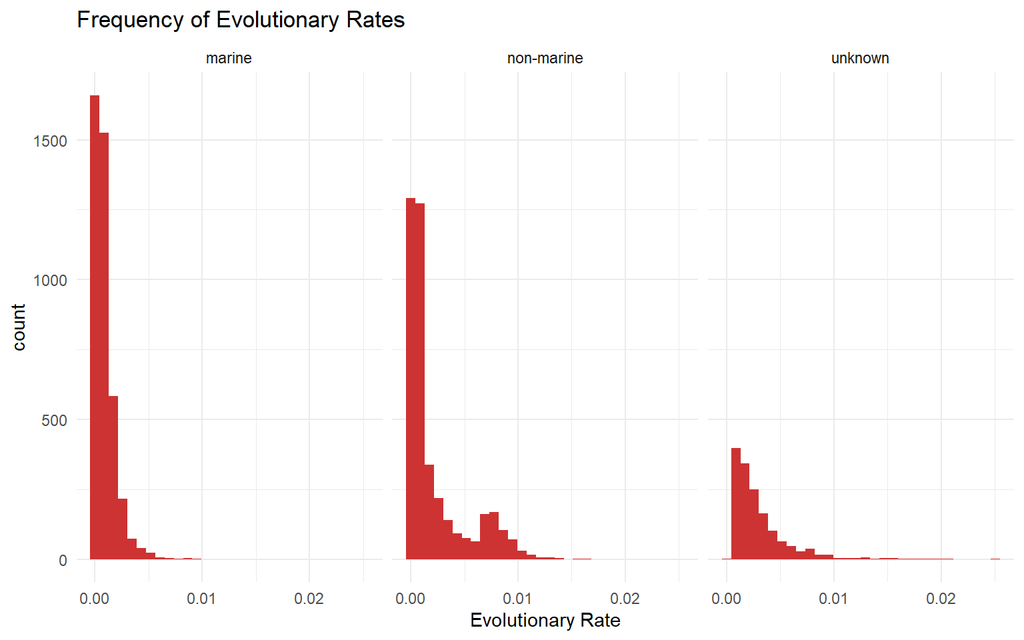

```r
#Getting rid of the NAs
data %>% filter(!is.na(habitat)) %>%
#Plotting!
ggplot(aes(x=rate))+
  geom_histogram(fill="brown3")+
  theme_minimal()+
  labs(title="Frequency of Evolutionary Rates", x="Evolutionary Rate")+
  #Plot, as a grid
  facet_grid(~habitat)
```

Interesting! So we’re seeing a lot of 0s, which makes sense, but we’re also seeing that the non-marine clades have a second high spike and a wider overall distribution. Unknown are just horseshoe crabs whose environmental affinity I haven’t added in yet.

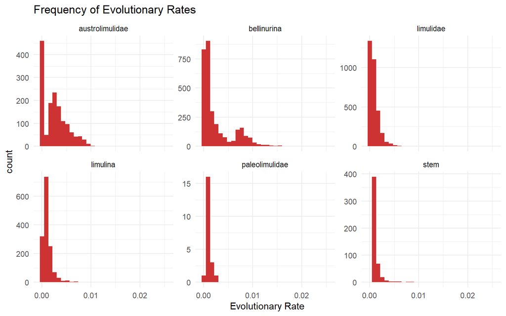

```r
#Get rid of the NA values
data %>% filter(!is.na(clade)) %>%
  #Plot, as a grid, with differing y-scales.
ggplot(aes(x=rate))+
  geom_histogram(fill='brown3')+
  facet_wrap(~clade, scales="free_y")+
  theme_minimal()+
  labs(title="Frequency of Evolutionary Rates", x="Evolutionary Rate")
```

Okay, so when we look at clades, we’re still seeing most rates at 0; however, the two non-marine clades still have a wider distribution and higher average!

Now let’s do rates in time.

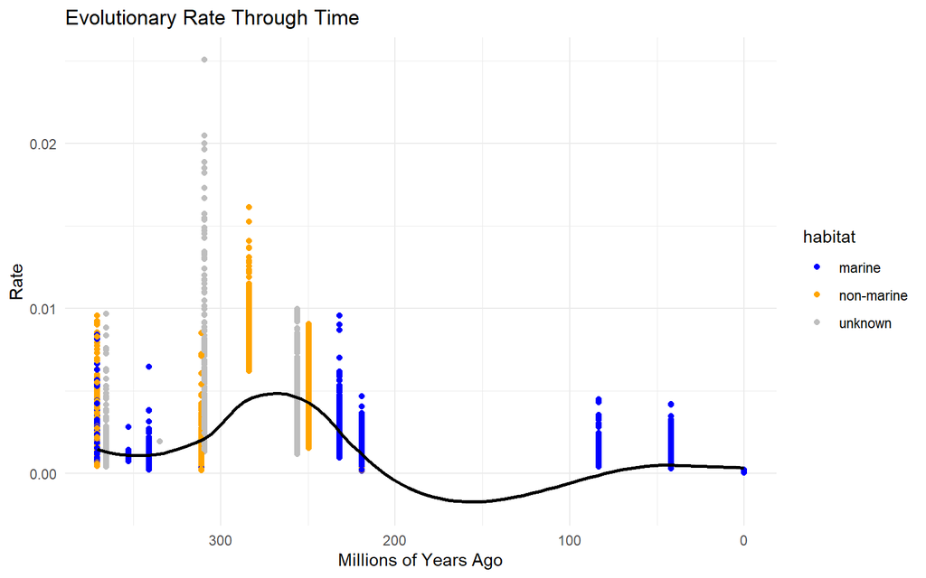

```r
data %>% filter(!is.na(mid)) %>%
  ggplot(aes(x=mid, y=rate))+
  geom_point(aes(col=habitat))+
  scale_color_manual(values=c("blue", "orange", "gray"))+
  scale_x_reverse()+
  geom_smooth(method="loess", col="black")+
  theme_minimal()+
  labs(title="Evolutionary Rate Through Time", x="Millions of Years Ago", y="Rate")
```

Interesting! It looks like the highest rates were happening in the Devonian/Carboniferous/Permian, and that they’ve been kind of slowing down.

## Python plots

Let’s make the same graphs in python!

```python
import numpy as np
import pandas as pd
import matplotlib.pyplot as plt
from Bio import Phylo
from Bio.Phylo.Consensus import *
```

Let’s read in our data!

```python
 #Reading in csv as a pandas dataframe
PyData = pd.read_csv("Data/rate_by_hand.csv")

 #Python doesn't play as well as R with NAs so let's just go ahead and get rid of them
PyData = PyData.dropna()

PyData.head()
```

```
##     Unnamed: 0                           names  ...      rate    tree
## 0            1           Anacontium_carpenteri  ...  0.006688  tree 1
## 1            2                Andersoniella_sp  ...  0.000245  tree 1
## 2            3  Batracholimulus_fuchsbergensis  ...  0.000220  tree 1
## 3            4         Belinurus_trilobitoides  ...  0.001071  tree 1
## 46          47    Carcinoscorpius_rotundicauda  ...  0.000105  tree 1
##
## [5 rows x 15 columns]
```

Excellent! Let’s start with a scatter plot or rate vs mid.

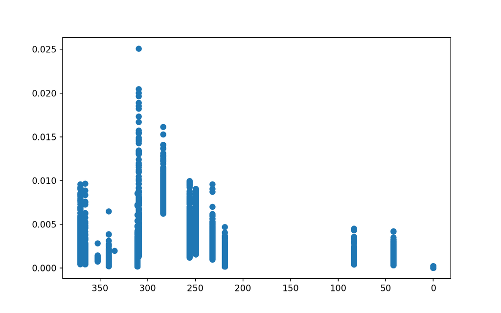

```python
#Plotting it out, with an inverse x axis because this represents geological time
plt.scatter(PyData['mid'], PyData['rate'])
plt.gca().invert_xaxis()
plt.show()
```

Okay, so I haven’t yet plotted a tree in python, so I’m trying now, with the original tree we started out with!

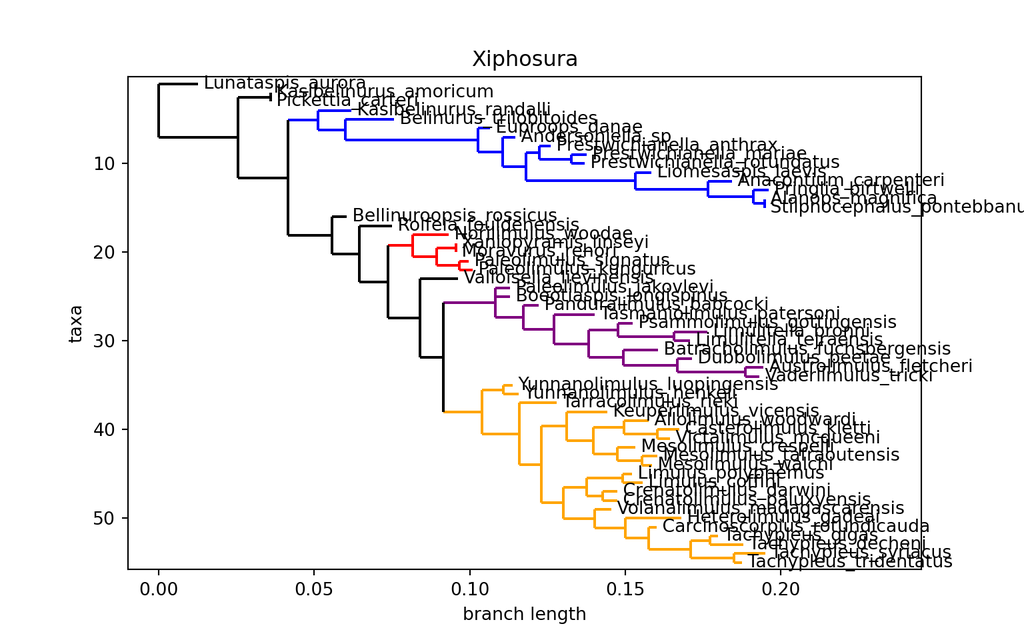

```python
#Read in my tree
tree = Phylo.read("Data/xipho_tree_updated.tre", "nexus")
#Organize it so the deepest clades are at the top
tree.ladderize()
#Color the Clades
bellinurina = tree.common_ancestor('Kasibelinurus_randalli', 'Prestwichianella_anthrax')
bellinurina.color='blue'

limulidae = tree.common_ancestor('Yunnanolimulus_luopingensis', 'Carcinoscorpius_rotundicauda')
limulidae.color='orange'

paleolimulidae = tree.common_ancestor('Norilimulus_woodae', 'Paleolimulus_signatus')
paleolimulidae.color='red'

austrolimulidae = tree.common_ancestor('Boeotiaspis_longispinus', 'Dubbolimulus_peetae')
austrolimulidae.color='purple'

#Give it a name
tree.name='Xiphosura'
#plot it!
Phylo.draw(tree)
```